# Global Dashboard of Novel Carona Virus Cases

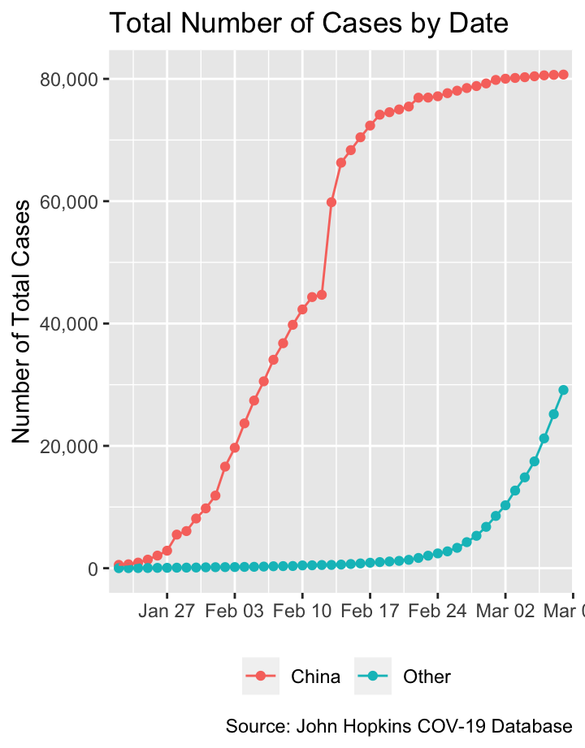

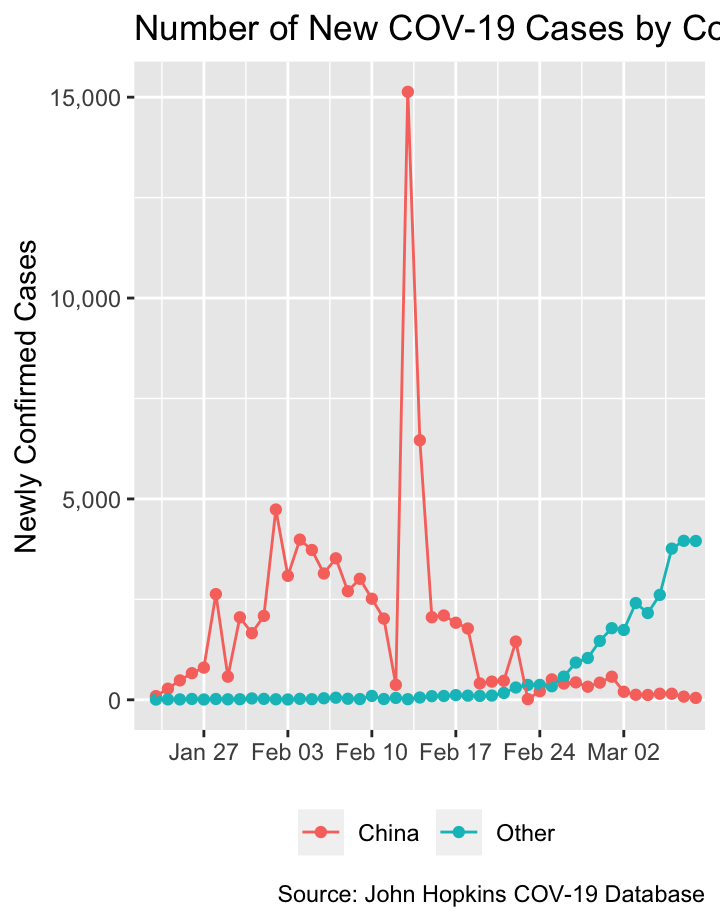

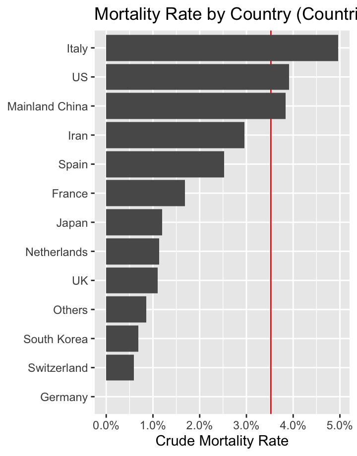

### Total Cumulative Cases

| Total Countries Infected | Total Cases | Total Deaths | Mortality Rate % | Total Recovered |
| --- | --- | --- | --- | --- |
| 107 | 109835 | 3803 | 3.462466 | 60695 |

### Map of Cases By Country

[interactive chart not shown]

### Cumulative Cases By Country

| country | Total Cases | Total Deaths | Total Recovered | Active Cases | Mortality Rate % |
| --- | --- | --- | --- | --- | --- |
| Mainland China | 80699 | 3097 | 57320 | 20282 | 3.8377179 |
| Italy | 7375 | 366 | 622 | 6387 | 4.9627119 |
| Iran | 6566 | 194 | 2134 | 4238 | 2.9546147 |
| South Korea | 7314 | 50 | 118 | 7146 | 0.6836205 |
| US | 537 | 21 | 8 | 508 | 3.9106145 |
| France | 1126 | 19 | 12 | 1095 | 1.6873890 |
| Spain | 673 | 17 | 30 | 626 | 2.5260030 |
| Iraq | 60 | 6 | 0 | 54 | 10.0000000 |
| Japan | 502 | 6 | 76 | 420 | 1.1952191 |
| Others | 696 | 6 | 40 | 650 | 0.8620690 |
| Australia | 76 | 4 | 21 | 51 | 5.2631579 |
| Hong Kong | 114 | 3 | 58 | 53 | 2.6315789 |
| Netherlands | 265 | 3 | 0 | 262 | 1.1320755 |
| UK | 273 | 3 | 18 | 252 | 1.0989011 |
| Switzerland | 337 | 2 | 3 | 332 | 0.5934718 |
| Argentina | 12 | 1 | 0 | 11 | 8.3333333 |
| Egypt | 49 | 1 | 1 | 47 | 2.0408163 |
| Philippines | 10 | 1 | 1 | 8 | 10.0000000 |
| San Marino | 36 | 1 | 0 | 35 | 2.7777778 |
| Taiwan | 45 | 1 | 13 | 31 | 2.2222222 |
| Thailand | 50 | 1 | 31 | 18 | 2.0000000 |
| Afghanistan | 4 | 0 | 0 | 4 | 0.0000000 |
| Algeria | 19 | 0 | 0 | 19 | 0.0000000 |
| Andorra | 1 | 0 | 0 | 1 | 0.0000000 |
| Armenia | 1 | 0 | 0 | 1 | 0.0000000 |
| Austria | 104 | 0 | 0 | 104 | 0.0000000 |
| Azerbaijan | 9 | 0 | 0 | 9 | 0.0000000 |
| Bahrain | 85 | 0 | 4 | 81 | 0.0000000 |
| Bangladesh | 3 | 0 | 0 | 3 | 0.0000000 |
| Belarus | 6 | 0 | 0 | 6 | 0.0000000 |

[output cut: 78 more lines]

### Cumulative Case Data

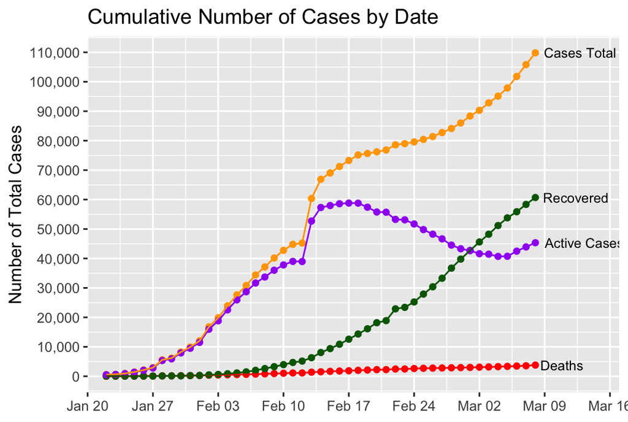

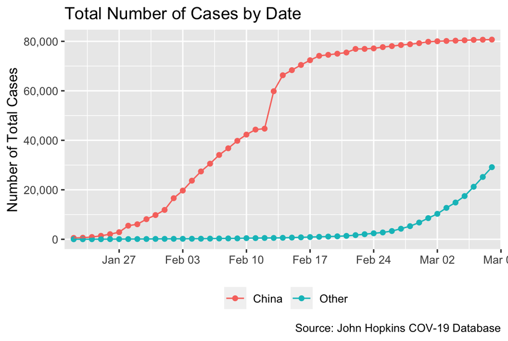

### New Cases by Date

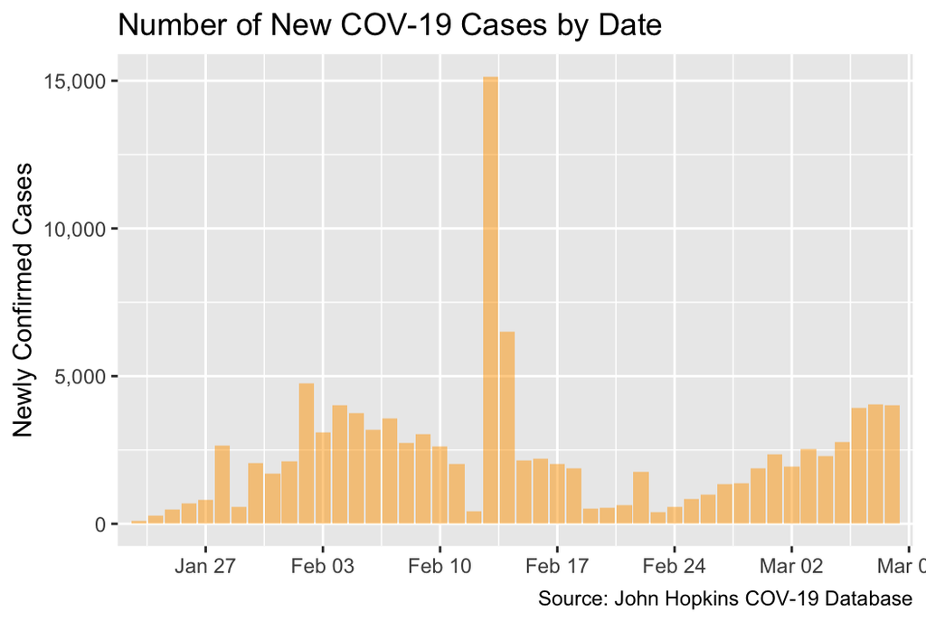

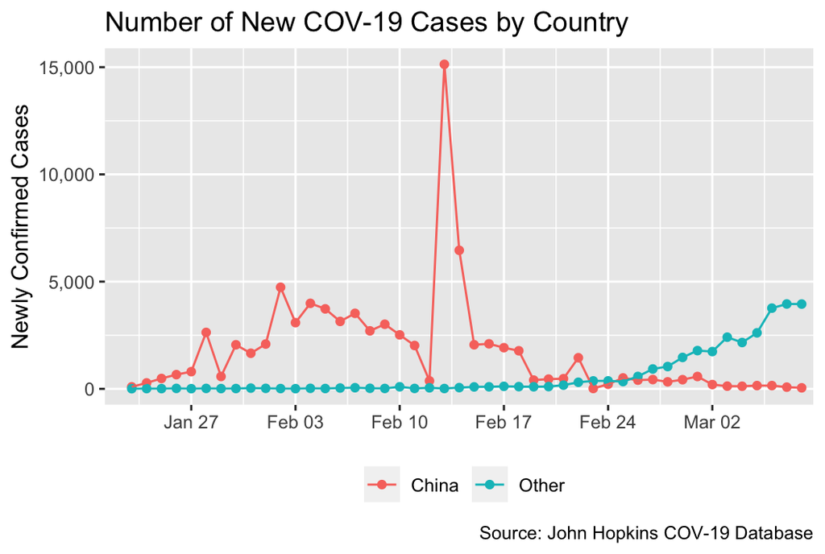

### Country Information

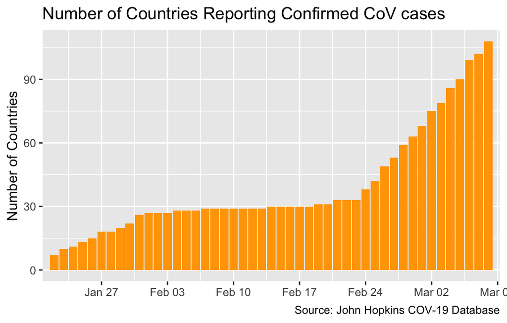

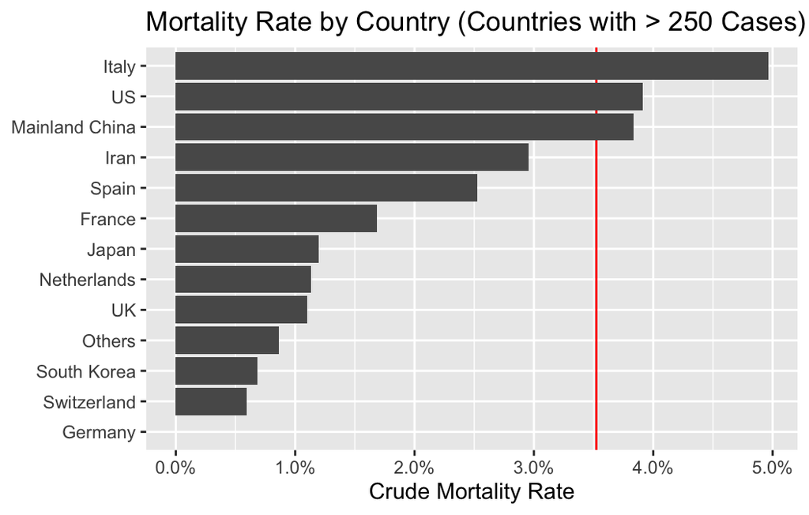

#### Information and resources

CoV-19 is a is a novel Carona virus that was furst reported in Wuhan, China on January 20, 2020.

The virus is highly transmissable and spread:

- Between people who are in close contact with one another (within about 6 feet).
- Through respiratory droplets produced when an infected person coughs or sneezes.

People infeced with the virus are most contageous when they are sick, but in some cases the virus can be spread before symptoms arise

The [CDC Website has more useful information](https://www.cdc.gov/coronavirus/2019-ncov/about/transmission.html)

The [WHO Emergency Response site](https://experience.arcgis.com/experience/685d0ace521648f8a5beeeee1b9125cd) also contains information on the global response to this epidemic.

ESRI has created a similar dashboard that now requires login credentials to view link

All data for this dashboard was taken from the John’s Hopkins daily CoV database hosted on [humanitarian data exchange] (https://data.humdata.org/dataset/novel-coronavirus-2019-ncov-cases)

The 2020 COV outbreak is an ongoing public health crisis and this dashboard will automatically update as more case data becomes availible

For any questions please contact: Christopher LeBoa (cleboa@stanford.edu)

**Things to add** - mortality rate by country – done - add country name to table if > 50 cases - add # cases to str glue cumulative graph – done - sizing of leaflet dots – ask bill - change C0v-19 by country to a line graph – done - # of new countries reporting cases per day – done